# DATA SCIENCE LATAM

UN ESPACIO PARA NUNCA PARAR DE APRENDER!!

Francisco Zambrano Cruz. Mayo 2020.

[figure not shown]

# Gráficos de series de tiempo

Cuando pensamos en el tiempo, pensamos en años, días, meses, horas, minutos y segundos. Piense en cualquier conjunto de datos y encontrará algunos atributos que estarán en forma de tiempo, especialmente datos relacionados con acciones, ventas, compras, ganancias y pérdidas. Por ejemplo, el precio de las acciones en la bolsa de valores en diferentes puntos en un día, mes o año determinado. Todos estos tienen tiempo asociado con ellos. En palabras simples, contiene **datos u observaciones en orden de tiempo**.

Lo primero que debe hacer en cualquier tarea de análisis de datos es trazar los datos. Los gráficos permiten visualizar muchas características de los datos, incluidos patrones, observaciones inusuales, cambios en el tiempo y relaciones entre variables.

Las características que se ven en los graficos de los datos deben incorporarse, tanto como sea posible, en los métodos de pronóstico que se utilizarán. Así como el tipo de datos determina qué método de pronóstico usar, también determina qué gráficos son apropiados. Pero antes de producir gráficos, necesitamos configurar nuestras series de tiempo en R.

## 1. Objeto ts

Una serie temporal puede considerarse como una lista de números, junto con información sobre las veces que se registraron esos números. Esta información puede almacenarse como un objeto ts en R.

Suponga que tiene observaciones anuales de los últimos años:

**Año** -> **obs**

2012 -> 123

2013 -> 39

2014 -> 78

2015 -> 52

2016 -> 110

Si tiene datos anuales, con una observación por año, solo necesita proporcionar el año de inicio (o el año final).

```r
#Convertimos esto en un objeto ts usando la función ts():

y <- ts(c(123,39,78,52,110), start=2012)

#Time Series:
#Start = 2012
#End = 2016
#Frequency = 1
#[1] 123  39  78  52 110
```

Para las observaciones que son más frecuentes que una vez al año, simplemente agregue el argumento **frequency**.

Por ejemplo, si sus datos mensuales ya están almacenados como un vector numérico z, entonces se pueden convertir a un objeto ts como este:

```r
z = c(123,39,78,52,110,200,300,400,500,600,700,800)
y <- ts(z, start=2012, frequency=12)
```

```r
#     Jan Feb Mar Apr May Jun Jul Aug Sep Oct Nov Dec
#2012 123  39  78  52 110 200 300 400 500 600 700 800
```

Es importante almacenar los datos como un objeto de serie de tiempo (ts)

Examinemos el conjunto de datos **AirPassengers** que muestra a los pasajeros aéreos mensuales en miles desde 1949 hasta 1960. También crearemos nuevas series de tiempo para representar los datos.

```r
AirPassengers
```

```r
#     Jan Feb Mar Apr May Jun Jul Aug Sep Oct Nov Dec
#1949 112 118 132 129 121 135 148 148 136 119 104 118
#1950 115 126 141 135 125 149 170 170 158 133 114 140
#1951 145 150 178 163 172 178 199 199 184 162 146 166
#1952 171 180 193 181 183 218 230 242 209 191 172 194
#1953 196 196 236 235 229 243 264 272 237 211 180 201
#1954 204 188 235 227 234 264 302 293 259 229 203 229
#1955 242 233 267 269 270 315 364 347 312 274 237 278
#1956 284 277 317 313 318 374 413 405 355 306 271 306
#1957 315 301 356 348 355 422 465 467 404 347 305 336
#1958 340 318 362 348 363 435 491 505 404 359 310 337
#1959 360 342 406 396 420 472 548 559 463 407 362 405
#1960 417 391 419 461 472 535 622 606 508 461 390 432
```

```r
# Con la funcion class comprobamos que AirPassenger es un Serie de tiempo
class(AirPassengers)
```

'ts'

```r
# funcion start para conocer la fecha de inicio de la serie
start(AirPassengers)
```

1. 1949

2. 1

```r
# funcion end para conocer la fecha de fin de la serie
end(AirPassengers)
```

1. 1960

2. 12

```r
# mostramos las medidas de tendencia central
summary(AirPassengers)
```

```
   Min. 1st Qu.  Median    Mean 3rd Qu.    Max.
  104.0   180.0   265.5   280.3   360.5   622.0
```

**Creación de una serie temporal**

Supongamos que tenemos el precio de las acciones en el rango de 2500 a 4000 desde 2011 que se registrará mensualmente hasta el 2016.

```r
set.seed(123)
my_vector = sample (2500:4000, 72, replace = T)
```

```
#> my_vector
```

```r
#[1] 2914 2962 2678 3025 2694 3437 3641 3822 3752 3767 3537 3897 3164 3101 3208 3510 3614 3452 2847 3516
#[21] 3878 3339 2525 3018 3949 2710 3431 3092 3054 2872 3343 3666 3043 2989 3404 3436 3546 3422 3455 2808
#[41] 3658 3747 2665 2716 3813 3080 2571 3087 2640 3221 3358 2652 2793 2776 3986 2540 2930 2589 2815 3746
#[61] 3027 3639 3273 3246 2955 3097 3562 3682 3251 3732 2873 2533
```

```r
my_series = ts (my_vector, start = c (2011,1), end = c (2016,12), frequency  = 12)
```

```r
#     Jan  Feb  Mar  Apr  May  Jun  Jul  Aug  Sep  Oct  Nov  Dec
#2011 2914 2962 2678 3025 2694 3437 3641 3822 3752 3767 3537 3897
#2012 3164 3101 3208 3510 3614 3452 2847 3516 3878 3339 2525 3018
#2013 3949 2710 3431 3092 3054 2872 3343 3666 3043 2989 3404 3436
#2014 3546 3422 3455 2808 3658 3747 2665 2716 3813 3080 2571 3087
#2015 2640 3221 3358 2652 2793 2776 3986 2540 2930 2589 2815 3746
#2016 3027 3639 3273 3246 2955 3097 3562 3682 3251 3732 2873 2533
```

# 2. Frecuencia de una serie de tiempo

La **"frecuencia"** es el número de observaciones antes de que se repita el patrón estacional. Cuando se usa la función ts() en R, se deben usar las siguientes opciones.

**Frecuencias:**

Anual = 1

Trimestral = 4

Mensual = 12

Semanal = 52

```r
my_series2 = ts (my_vector, start = c (2011,1), end = c (2016,12), frequency  = 4)
```

```r
#     Qtr1 Qtr2 Qtr3 Qtr4
#2011 2914 2962 2678 3025
#2012 2694 3437 3641 3822
#2013 3752 3767 3537 3897
#2014 3164 3101 3208 3510
#2015 3614 3452 2847 3516
#2016 3878 3339 2525 3018
```

# 3. Gráficos de tiempo

Para los datos de series de tiempo, el gráfico para comenzar es un diagrama de tiempo. Es decir, las observaciones se trazan contra el tiempo de observación, con observaciones consecutivas unidas por líneas rectas.

La Figura a continuación muestra la carga de pasajeros clase económica semanal en Ansett Airlines entre las dos ciudades más grandes de Australia.

```r
# la libreria fpp2 proporciona data sets para series de tiempo

library(ggplot2)
library(fpp2)
```

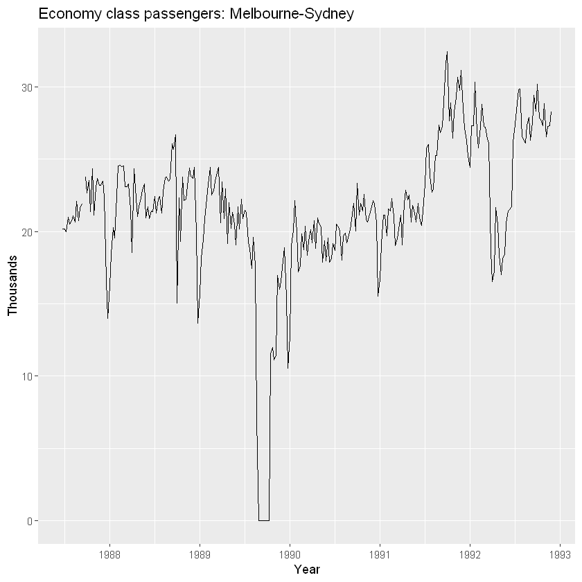

```r
autoplot(melsyd[,"Economy.Class"]) +
  ggtitle("Economy class passengers: Melbourne-Sydney") +
  xlab("Year") +
  ylab("Thousands")
```

**autoplot()** produce automáticamente un diagrama apropiado de lo que sea que le pase en el primer argumento.

En este caso, reconoce **melsyd[,"Economy.Class"]** como una serie de tiempo y produce un diagrama de tiempo.

El diagrama de tiempo revela inmediatamente algunas características interesantes.

- Hubo un período en 1989 en el que no se transportaron pasajeros, esto se debió a una disputa industrial.
- Hubo un período de carga reducida en 1992. Esto se debió a una prueba en la que algunos asientos de clase económica fueron reemplazados por asientos de clase ejecutiva.
- Se produjo un gran aumento en la carga de pasajeros en la segunda mitad de 1991.
- Hay algunas grandes caídas en la carga al comienzo de cada año. Estos se deben a los efectos de vacaciones.
- Hay una fluctuación a largo plazo en el nivel de la serie que aumenta durante 1987, disminuye en 1989 y aumenta nuevamente durante 1990 y 1991.
- Hay algunos períodos de observaciones faltantes.

Cualquier modelo deberá tener en cuenta todas estas características para pronosticar de manera efectiva la carga de pasajeros en el futuro.

Una serie de tiempo más simple se muestra en la Figura:

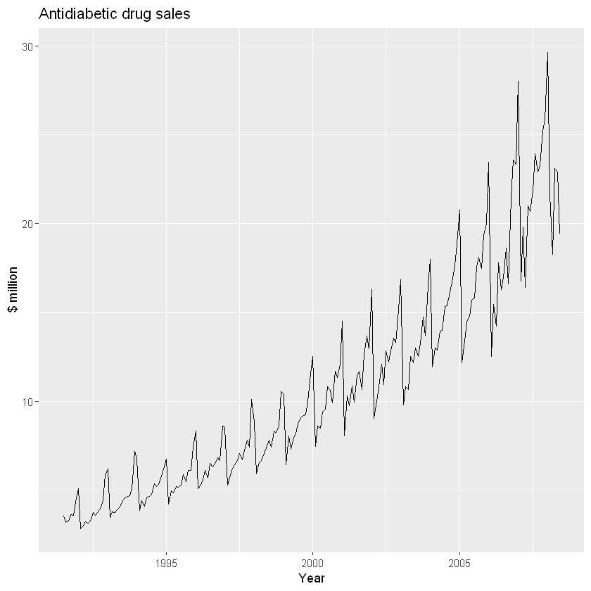

```r
autoplot(a10) +
  ggtitle("Antidiabetic drug sales") +
  ylab("$ million") +
  xlab("Year")
```

Aquí, hay una **tendencia clara y creciente**. También hay un **patrón estacional** fuerte que aumenta de tamaño a medida que aumenta el nivel de la serie. La caída repentina al comienzo de cada año es causada por un esquema de subsidio del gobierno que hace que sea rentable que los pacientes acumulen medicamentos al final del año calendario. Cualquier pronóstico de esta serie necesitaría capturar el patrón estacional y el hecho de que la tendencia está cambiando lentamente.